# Анализ программы лояльности

Наша цель проанализировать программу лояльности магазина строительных материалов «Строили, строили и наконец построили» - оценить результаты внедрения программы лояльности и понять стоит ли ее продолжать. Все покупатели могут получить доступ в магазин с использованием персональных карт. За 200 рублей в месяц они могут стать участниками программы лояльности. В программу включены скидки, специальные предложения, подарки.

В ходе анализа программы лояльности пройдем следующие этапы

1. Предобработка данных:
   - Поверить корректность наименований колонок;
   - Переименовать колонки;
   - Исследовать пропущенные значения;
   - Заменить/удалить пропущенные значения если необходимо;
   - Исследовать соответствие типов;
   - Привести типы;
   - Исследовать дубликаты;
   - Удалить дубликаты;
   - Исследовать аномальные значения;
   - Откорректировать аномальные значения.
2. Исследовательский анализ данных:
   - Определить минимальную и максимальную даты покупок;
   - Определить количество задействованных и не задействованных в программе лояльности покупателей;
3. Анализ программы лояльности;
   - Исследовать среднее количество покупок задействованных и не задействованных в программе лояльности покупателей;
   - Исследовать среднее количество товаров в чеке задействованных и не задействованных в программе лояльности покупателей;
   - Исследовать средний чек задействованных и не задействованных в программе лояльности покупателей;
   - Исследовать LTV задействованных и не задействованных в программе лояльности покупателей;
4. Проверка статистических гипотез.
   - Проверка гипотезы: средний чек участников программы лояльности выше, чем у остальных покупателей.
   - Проверка гипотезы: среднее количество товаров в чеке участников программы лояльности выше, чем у остальных покупателей.
5. Выводы и рекомендации.

Исходными данными для анализа являются датасеты product_codes и retail_dataset рассмотрим их структуру.

Файл retail_dataset.csv:

- `purchaseId` — id чека;
- `item_ID` — id товара;
- `purchasedate` — дата покупки;
- `Quantity` — количество товара;
- `CustomerID` — id покупателя;
- `ShopID` — id магазина;
- `loyalty_program` — участвует ли покупатель в программе лояльности;

Файл product_codes.csv:

- `productID` — id товара;
- `price_per_one` — стоимость одной единицы товара;

## Предобработка данных

Загрузим и изучим данные

```python
import pandas as pd
from datetime import datetime, timedelta
import matplotlib.pyplot as plt
%matplotlib inline
import seaborn as sns
import numpy as np
import seaborn as sns
sns.set_palette('pastel')
from scipy import stats as st
from plotly import graph_objects as go
import plotly.express as px
```

```python
try:
    costs, orders = (pd.read_csv('product_codes.csv'),
                   pd.read_csv('retail_dataset.csv'))
except:
    costs, orders = (pd.read_csv('product_codes.csv'),
                   pd.read_csv('retail_dataset.csv'))
```

```python
costs.info()
costs.head()
```

```
<class 'pandas.core.frame.DataFrame'>
RangeIndex: 9969 entries, 0 to 9968
Data columns (total 2 columns):
 #   Column         Non-Null Count  Dtype
---  ------         --------------  -----
 0   productID      9969 non-null   object
 1   price_per_one  9969 non-null   float64
dtypes: float64(1), object(1)
memory usage: 155.9+ KB
```

|  | productID | price_per_one |
| --- | --- | --- |
| 0 | 85123A | 2.55 |
| 1 | 71053 | 3.39 |
| 2 | 84406B | 2.75 |
| 3 | 84029G | 3.39 |
| 4 | 84029E | 3.39 |

```python
orders.info()
orders.head()
```

```
<class 'pandas.core.frame.DataFrame'>
RangeIndex: 105335 entries, 0 to 105334
Data columns (total 7 columns):
 #   Column           Non-Null Count   Dtype
---  ------           --------------   -----
 0   purchaseid       105335 non-null  object
 1   item_ID          105335 non-null  object
 2   Quantity         105335 non-null  int64
 3   purchasedate     105335 non-null  object
 4   CustomerID       69125 non-null   float64
 5   ShopID           105335 non-null  object
 6   loyalty_program  105335 non-null  float64
dtypes: float64(2), int64(1), object(4)
memory usage: 5.6+ MB
```

|  | purchaseid | item_ID | Quantity | purchasedate | CustomerID | ShopID | loyalty_program |
| --- | --- | --- | --- | --- | --- | --- | --- |
| 0 | 538280 | 21873 | 11 | 2016-12-10 12:50:00 | 18427.0 | Shop 0 | 0.0 |
| 1 | 538862 | 22195 | 0 | 2016-12-14 14:11:00 | 22389.0 | Shop 0 | 1.0 |
| 2 | 538855 | 21239 | 7 | 2016-12-14 13:50:00 | 22182.0 | Shop 0 | 1.0 |
| 3 | 543543 | 22271 | 0 | 2017-02-09 15:33:00 | 23522.0 | Shop 0 | 1.0 |
| 4 | 543812 | 79321 | 0 | 2017-02-13 14:40:00 | 23151.0 | Shop 0 | 1.0 |

Переименуем колонки, приведем названия к нижнему регистру.

```python
costs=costs.rename(columns={'productID':'product_id'})
orders.columns = orders.columns.str.lower()
orders=(orders
        .rename(columns={'purchaseid':'purchase_id', 'purchasedate':'purchase_datetime',
                         'customerid':'customer_id','shopid':'shop_id', 'item_id':'product_id'}))
```

Проверим данные на наличие пропущеных значений

```python
costs.isna().sum()
```

```
product_id       0
price_per_one    0
dtype: int64
```

```python
orders.isna().sum()
```

```
purchase_id              0
product_id               0
quantity                 0
purchase_datetime        0
customer_id          36210
shop_id                  0
loyalty_program          0
dtype: int64
```

```python
print('В колонке customer_id пропущено', round(orders['customer_id'].isna().sum()*100/len(orders),2),'% значений.')
```

```
В колонке customer_id пропущено 34.38 % значений.
```

Пропусков слишком много, чтобы их чем-то заменить или удалить, заполним их маркерами в виде 0.

```python
orders['customer_id'] = orders['customer_id'].fillna(0)
```

- Приведем столбцы 'customer_id' и 'loyalty_program' к целочисленному типу.
- Преобразуем данные в столбце 'purchase_datetime' к типу datetime.
- Создадим столбец 'purchase_date' с датой покупки.

```python
orders['loyalty_program'] = orders['loyalty_program'].astype('bool')
orders['customer_id'] = orders['customer_id'].astype('int64')
orders['purchase_datetime'] = pd.to_datetime(orders['purchase_datetime'])
orders['purchase_date'] = pd.to_datetime(orders['purchase_datetime']).dt.date
orders['purchase_date'] = pd.to_datetime(orders['purchase_date'])
orders.info()
```

```
<class 'pandas.core.frame.DataFrame'>
RangeIndex: 105335 entries, 0 to 105334
Data columns (total 8 columns):
 #   Column             Non-Null Count   Dtype
---  ------             --------------   -----
 0   purchase_id        105335 non-null  object
 1   product_id         105335 non-null  object
 2   quantity           105335 non-null  int64
 3   purchase_datetime  105335 non-null  datetime64[ns]
 4   customer_id        105335 non-null  int64
 5   shop_id            105335 non-null  object
 6   loyalty_program    105335 non-null  bool
 7   purchase_date      105335 non-null  datetime64[ns]
dtypes: bool(1), datetime64[ns](2), int64(2), object(3)
memory usage: 5.7+ MB
```

Проверим данные на наличие дубликатов.

```python
 print(f'Обнаружено {costs.duplicated().sum()} явных дубликатов.')
```

```
Обнаружено 0 явных дубликатов.
```

```python
 print(f'Обнаружено {orders.duplicated().sum()} явных дубликатов.')
```

```
Обнаружено 1033 явных дубликатов.
```

Удалим дубликаты в датафрейме orders.

```python
orders = orders.drop_duplicates().reset_index(drop=True)
```

Обработаем аномалии в данных. В колонке 'quantity' видим отрицательные значения, это возможно возвраты, номер чека таких позиций начинается с буквы "C", изучим их поподробнее.

```python
orders.query('customer_id==18106 and product_id in ["22636", "22300", "22634"]')
```

|  | purchase_id | product_id | quantity | purchase_datetime | customer_id | shop_id | loyalty_program | purchase_date |
| --- | --- | --- | --- | --- | --- | --- | --- | --- |
| 190 | 536861 | 22634 | 7 | 2016-12-03 10:44:00 | 18106 | Shop 4 | False | 2016-12-03 |
| 16494 | C539866 | 22636 | -3 | 2016-12-23 10:20:00 | 18106 | Shop 4 | False | 2016-12-23 |
| 29420 | C539866 | 22300 | -4 | 2016-12-23 10:20:00 | 18106 | Shop 4 | False | 2016-12-23 |
| 58696 | 536861 | 22300 | 5 | 2016-12-03 10:44:00 | 18106 | Shop 4 | False | 2016-12-03 |
| 87634 | C539866 | 22634 | -5 | 2016-12-23 10:20:00 | 18106 | Shop 4 | False | 2016-12-23 |
| 97748 | 536861 | 22636 | 7 | 2016-12-03 10:44:00 | 18106 | Shop 4 | False | 2016-12-03 |

Покупатель с ID18106 03.12.2016 купил 3 разных наименования товара, 23.12.2016 видим те же наименования товара с отрицательным количеством, очень похоже на возвраты.

```python
orders.query('customer_id==23956')
```

|  | purchase_id | product_id | quantity | purchase_datetime | customer_id | shop_id | loyalty_program | purchase_date |
| --- | --- | --- | --- | --- | --- | --- | --- | --- |
| 44303 | C542086 | 22423 | -2 | 2017-01-25 12:34:00 | 23956 | Shop 0 | True | 2017-01-25 |

А у покупателя с ID 23956 всего одна покупка и та с отрицательным количеством, можно предположить, что это возврат и товар был куплен до начала анализируемого периода, но обычно товары можно вернуть в течении 2-х недель после покупки, а наш товар вернули 25.01.2017, то есть почти через 2 месяца после покупки.

Доказать, что отрицательные значения количества товаров это все возвраты мы не можем, в любом случае возвраты нужно анализировать отдельно, потому удалим из данных строки с отрицательным количеством.

Так же видим товары с 0-вым количеством предполагаю, что так отображаются акционные товары например в случае акции типа "2+1". Так как у нас нет информации проходила акция в рамках программы лояльности, либо она распространялась на всех покупателей удалим строки с 0-м количеством и удалим выбросы.

```python
orders = orders.query('quantity>0')
orders = orders.loc[orders['quantity'] < np.quantile(orders['quantity'], 0.99)]
```

В ходе предобработки данных мы:

- Переименовали колонки;
- Выяснили, что в колонке customer_id пропущено 34.38 % значений, оставили пропуски так как их слишком много, чтобы удалить и не внести искажения в данные;
- Привели в соответствие типы данных;
- Не обнаружили дубликатов в датафрейме costs;
- Удалили дубликаты в датафрейме orders;
- Проанализировали аномальные значения в колонке 'quantity', удалили выбросы.

  ## Исследовательский анализ данных

```python
print('Минимальная дата покупки:', orders['purchase_datetime'].min().date())
print('Максимальная дата покупки:', orders['purchase_datetime'].max().date())
print('Мы располагаем данными за период:', orders['purchase_datetime'].max().date()-orders['purchase_datetime'].min().date())
print(f'Всего {orders.customer_id.nunique()} покупателей.')
print(orders.query('loyalty_program == 1')['customer_id'].nunique(),'из них состоят в программе лояльности')
print('Это', round(orders.query('loyalty_program == 1')['customer_id'].nunique()*100/orders['customer_id'].nunique(),2),'% покупателей.')
```

```
Минимальная дата покупки: 2016-12-01
Максимальная дата покупки: 2017-02-28
Мы располагаем данными за период: 89 days, 0:00:00
Всего 1650 покупателей.
551 из них состоят в программе лояльности
Это 33.39 % покупателей.
```

В таблице costs одному товару соответствует несколько цен. Мы располагаем данными за период около 3-х месяцев, который включает в себя декабрь - период покупок к новому году и Рождеству, за этот период цена закономерно менялась. Для дальнейших расчетов расчитаем среднюю цену.

Объединим таблицы orders и costs.

```python
costs_grouped = costs.groupby('product_id')['price_per_one'].mean().reset_index()
data = orders.merge(
    costs_grouped[['product_id', 'price_per_one']], on='product_id', how='left'
)
data['total'] = data['quantity']*data['price_per_one']
data.head()
```

|  | purchase_id | product_id | quantity | purchase_datetime | customer_id | shop_id | loyalty_program | purchase_date | price_per_one | total |
| --- | --- | --- | --- | --- | --- | --- | --- | --- | --- | --- |
| 0 | 538280 | 21873 | 11 | 2016-12-10 12:50:00 | 18427 | Shop 0 | False | 2016-12-10 | 1.810000 | 19.910000 |
| 1 | 538855 | 21239 | 7 | 2016-12-14 13:50:00 | 22182 | Shop 0 | True | 2016-12-14 | 1.474000 | 10.318000 |
| 2 | 541424 | 79321 | 1 | 2017-01-17 17:57:00 | 0 | Shop 0 | False | 2017-01-17 | 7.013636 | 7.013636 |
| 3 | 537795 | 82494L | 5 | 2016-12-08 13:03:00 | 22892 | Shop 0 | True | 2016-12-08 | 5.145000 | 25.725000 |
| 4 | 541696 | 22197 | 4 | 2017-01-20 18:08:00 | 0 | Shop 0 | False | 2017-01-20 | 1.215000 | 4.860000 |

Известно, что участники программы лояльности платят дополнительно 200 руб.. в месяц, отобразим это в данных. Так как мы не знаем когда конкретно списывается стоимость программы лояльности, распределим ее стоимость на весь месяц.

```python
data['month'] = data['purchase_datetime'].astype('datetime64[M]')
lp_price =200
# сгруппируем покупателей по ид и месяцу покупки
lp_data = data.query('loyalty_program==1').groupby(['customer_id','month'])['purchase_id'].count().reset_index()
# разделим цену программы лояльности на количество покупок в месяц
lp_data['lp_price']=lp_price/lp_data['purchase_id']
data = data.merge(lp_data[['lp_price','customer_id', 'month']], on=['customer_id', 'month'], how='left')
data['lp_price']=data['lp_price'].fillna(0)
data['revenue']=data['lp_price']+data['total']
data.head(2)
```

|  | purchase_id | product_id | quantity | purchase_datetime | customer_id | shop_id | loyalty_program | purchase_date | price_per_one | total | month | lp_price | revenue |
| --- | --- | --- | --- | --- | --- | --- | --- | --- | --- | --- | --- | --- | --- |
| 0 | 538280 | 21873 | 11 | 2016-12-10 12:50:00 | 18427 | Shop 0 | False | 2016-12-10 | 1.810 | 19.910 | 2016-12-01 | 0.000000 | 19.910000 |
| 1 | 538855 | 21239 | 7 | 2016-12-14 13:50:00 | 22182 | Shop 0 | True | 2016-12-14 | 1.474 | 10.318 | 2016-12-01 | 6.896552 | 17.214552 |

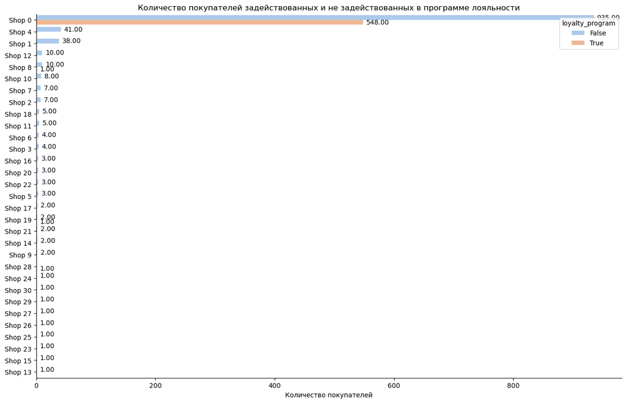

```python
data_p=(data.groupby(['loyalty_program','shop_id'])['customer_id'].nunique()
    .reset_index().sort_values(by='customer_id', ascending=False))
plt.figure(figsize=(16,10))
fig = sns.barplot(data=data_p, x='customer_id', y='shop_id', hue='loyalty_program')
for p in fig.patches:
    fig.annotate(format(p.get_width(), '.2f'),
                  xy=(p.get_width(),p.get_y()+p.get_height()/2),
                  xytext=(5,0),
                  textcoords='offset points',
                  ha='left',
                  va='center',
                  color='black')
plt.title('Количество покупателей задействованных и не задействованных в программе лояльности')
plt.ylabel(None)
plt.xlabel('Количество покупателей')
sns.despine()
```

Наибольшее число покупателей относится к магазину Shop 0, можно предположить, что это крупнейший магазин сети, покупателей по программе лояльности вполовину меньше чем остальных, посмотрим на данные по остальным магазинам.

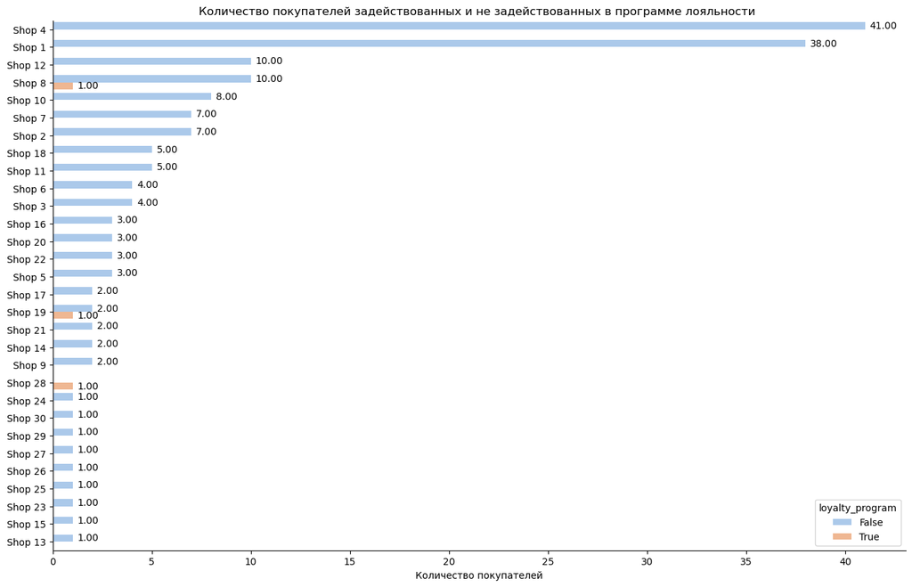

```python
plt.figure(figsize=(16,10))
fig = sns.barplot(data=data_p.query('shop_id!="Shop 0"'), x='customer_id', y='shop_id', hue='loyalty_program')
for p in fig.patches:
    fig.annotate(format(p.get_width(), '.2f'),
                  xy=(p.get_width(),p.get_y()+p.get_height()/2),
                  xytext=(5,0),
                  textcoords='offset points',
                  ha='left',
                  va='center',
                  color='black')
plt.title('Количество покупателей задействованных и не задействованных в программе лояльности ')
plt.ylabel(None)
plt.xlabel('Количество покупателей')
sns.despine()
```

Программа лояльности действует только в четырех магазинах сети это Shop 19, Shop 0, Shop 8 и Shop 28.

```python
data.query('shop_id =="Shop 28"').groupby(['loyalty_program','shop_id'])['total'].count().reset_index()
```

|  | loyalty_program | shop_id | total |
| --- | --- | --- | --- |
| 0 | True | Shop 28 | 30 |

В Shop 28 представленны данные только по участникам программы лояльности, возможно это оптовый магазин, в любом случае для нашего анализа Shop 28 другие магазины в которых нет данных по программе лояльности не подходят, удалим их из датасета.

```python
shops = ['Shop 0', 'Shop 19', 'Shop 8']
data_filtr = data.query('shop_id in @shops')
```

## Анализ программы лояльности

### Анализ количества покупок.

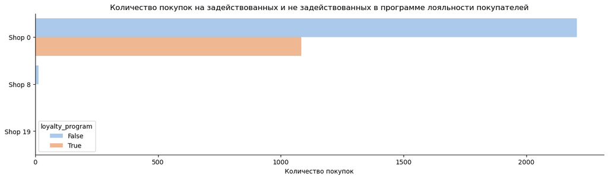

```python
data_shops=(data_filtr.groupby(['loyalty_program','shop_id'])['purchase_id'].nunique()
    .reset_index().sort_values(by='purchase_id', ascending=False))
plt.figure(figsize=(16,4))
fig1 = sns.barplot(data=data_shops, x='purchase_id', y='shop_id', hue='loyalty_program')
for p in fig1.patches:
    fig.annotate(format(p.get_width(), '.2f'),
                  xy=(p.get_width(),p.get_y()+p.get_height()/2),
                  xytext=(5,0),
                  textcoords='offset points',
                  ha='left',
                  va='center',
                  color='black')
plt.title('Количество покупок на задействованных и не задействованных в программе лояльности покупателей')
plt.ylabel(None)
plt.xlabel('Количество покупок')
sns.despine()
```

Количество покупок в магазине Shop 0 без программы лояльности в 2 раза выше чем с ней.

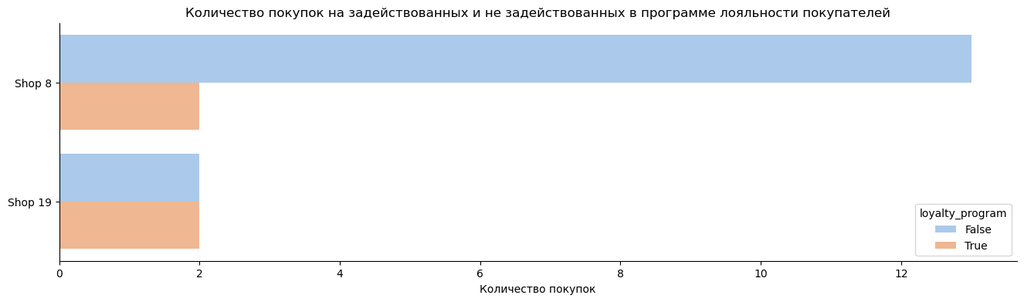

```python
data_shops=(data_filtr.query('shop_id!="Shop 0"').groupby(['loyalty_program','shop_id'])['purchase_id'].nunique()
    .reset_index().sort_values(by='purchase_id', ascending=False))
plt.figure(figsize=(16,4))
fig1 = sns.barplot(data=data_shops, x='purchase_id', y='shop_id', hue='loyalty_program')
for p in fig1.patches:
    fig.annotate(format(p.get_width(), '.2f'),
                  xy=(p.get_width(),p.get_y()+p.get_height()/2),
                  xytext=(5,0),
                  textcoords='offset points',
                  ha='left',
                  va='center',
                  color='black')
plt.title('Количество покупок на задействованных и не задействованных в программе лояльности покупателей')
plt.ylabel(None)
plt.xlabel('Количество покупок')
sns.despine()
```

Посмотрим на количество покупок в динамике.

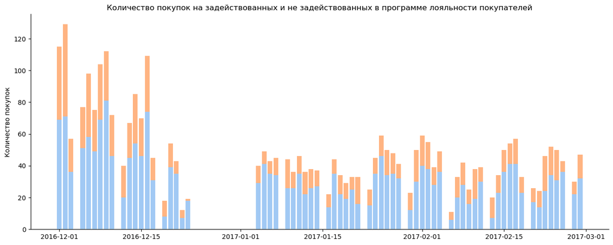

```python
df = data_filtr.groupby(['loyalty_program','purchase_date'])['purchase_id'].nunique().reset_index()
plt.figure(figsize=(16,6))
plt.bar(df.query('loyalty_program==False')['purchase_date'], df.query('loyalty_program==False')['purchase_id']);
plt.bar(df.query('loyalty_program==True')['purchase_date'], df.query('loyalty_program==True')['purchase_id'],
        bottom = df.query('loyalty_program==False')['purchase_id']);
plt.title('Количество покупок на задействованных и не задействованных в программе лояльности покупателей')
plt.ylabel('Количество покупок')
plt.xlabel(None)
sns.despine()
```

В динамике ситуация такая же - участники программы лояльности делают меньше покупок, чем остальные покупатели, на графике видим пик соответсвующий времени покупки подарков к Рождеству и затем выходные в работе сети во время рождественских каникул. Так же не стоит забывать, что участников программы лояльности меньше чем остальных покупателей, потому исследуем среднее количество покупок задействованных и не задействованных в программе лояльности покупателей.

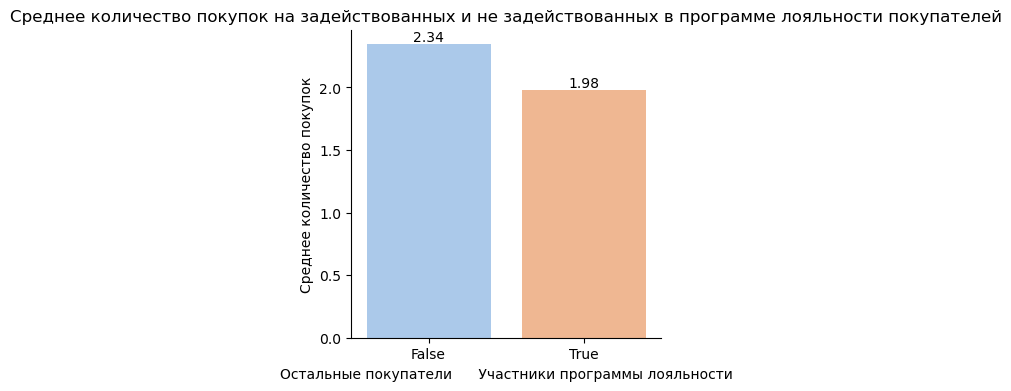

```python
data_ph = (data_filtr
           .groupby(['loyalty_program','customer_id'])['purchase_id'].nunique().reset_index()
           .groupby('loyalty_program')['purchase_id'].mean().reset_index())
plt.figure(figsize=(4,4))
graph = sns.barplot(x='loyalty_program', y='purchase_id', data=data_ph)
for p in graph.patches:
    graph.annotate('{:.2f}'.format(p.get_height()),
                  (p.get_x()+0.4, p.get_height()),
                  ha='center',
                  va='bottom',
                  color='black')
plt.title('Среднее количество покупок на задействованных и не задействованных в программе лояльности покупателей')
plt.ylabel('Среднее количество покупок')
plt.xlabel('Остальные покупатели      Участники программы лояльности')
sns.despine()
```

Участники программы лояльности совершают в среднем 1.98 покупки, остальные покупатели - 2.34, разница не в пользу участников программы лояльности.

В ходе анализа количества покупок мы выяснили, что хоть участников программы лояльности меньше и они делают значительно меньше покупок чем остальные покупатели, в среднем участники программы лояльности покупают реже, чем остальные покупатели магазина.

### Анализ среднего количества товаров в чеке

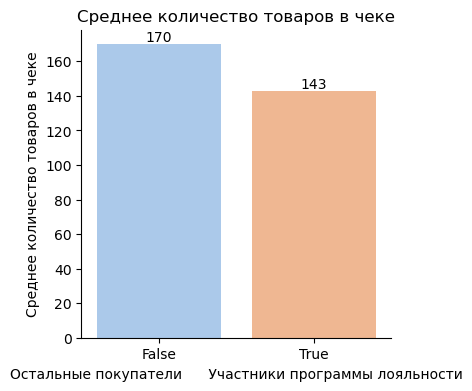

```python
data_qw = (data_filtr.groupby(['loyalty_program','purchase_id'])['quantity'].sum().
           reset_index().groupby('loyalty_program')['quantity'].mean().reset_index())
plt.figure(figsize=(4,4))
graph = sns.barplot(x='loyalty_program', y='quantity', data=data_qw)
for p in graph.patches:
    graph.annotate('{:.0f}'.format(p.get_height()),
                  (p.get_x()+0.4, p.get_height()),
                  ha='center',
                  va='bottom',
                  color='black')
plt.title('Среднее количество товаров в чеке')
plt.ylabel('Среднее количество товаров в чеке')
plt.xlabel('Остальные покупатели      Участники программы лояльности')
sns.despine()
```

Среднее количество товаров в чеке участников программы лояльности ниже чем у других покупателей, далее проверим это дополнительно при помощи статистических методов.

### Анализ среднего чека

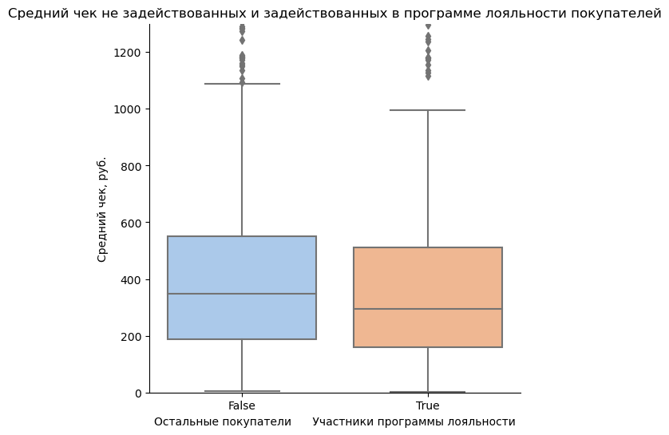

```python
avg_bill = (data_filtr.groupby(['loyalty_program','customer_id','purchase_id'])['total'].sum()
            .reset_index()
            .groupby(['loyalty_program','customer_id'])['total']
            .mean().reset_index()
            .rename(columns={'total':'avg_bill'}))
plt.figure(figsize=(6,6))
sns.boxplot(x='loyalty_program', y='avg_bill', data=avg_bill)
plt.ylim(0,1300)
plt.title('Cредний чек не задействованных и задействованных в программе лояльности покупателей')
plt.xlabel('Остальные покупатели      Участники программы лояльности')
plt.ylabel('Средний чек, руб.')
sns.despine()
```

Медианное значение среднего чека участников программы лояльности ниже чем у остальных покупателей, далее проверим насколько результаты статистически отличаются.

Посмотрим на средний чек в динамике

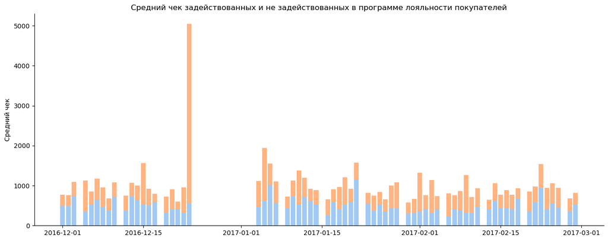

```python
avg_bill_date = (data_filtr.groupby(['loyalty_program','purchase_date','purchase_id'])['total'].sum()
            .reset_index()
            .groupby(['loyalty_program','purchase_date'])['total']
            .mean().reset_index()
            .rename(columns={'total':'avg_bill'}))
plt.figure(figsize=(16,6))
plt.bar(avg_bill_date.query('loyalty_program==False')['purchase_date'],
        avg_bill_date.query('loyalty_program==False')['avg_bill']);
plt.bar(avg_bill_date.query('loyalty_program==True')['purchase_date'],
        avg_bill_date.query('loyalty_program==True')['avg_bill'],
        bottom = avg_bill_date.query('loyalty_program==False')['avg_bill']);
plt.title('Средний чек задействованных и не задействованных в программе лояльности покупателей')
plt.ylabel('Средний чек')
plt.xlabel(None)
sns.despine()
```

В динамике средний чек участников программы лояльности, чуть ниже чем остальных покупателей, выделяеться пик в последний день перед каникулами, участники программы лояльности показали аномально большой средний чек, возможно это связано с какой нибудь предпраздничной акцией.

```python
(data_filtr.query('purchase_date == "2016-12-23"')
 .groupby(['loyalty_program','customer_id','purchase_id'])['revenue'].sum().reset_index())
```

|  | loyalty_program | customer_id | purchase_id | revenue |
| --- | --- | --- | --- | --- |
| 0 | False | 0 | 539952 | 31.157000 |
| 1 | False | 0 | 539955 | 436.488536 |
| 2 | False | 0 | 539958 | 4049.139500 |
| 3 | False | 0 | 539979 | 12.782500 |
| 4 | False | 0 | 539986 | 14.633333 |
| 5 | False | 0 | 539990 | 7.686667 |
| 6 | False | 0 | 539991 | 12.830833 |
| 7 | False | 18427 | 539953 | 4.883333 |
| 8 | False | 18844 | 539978 | 976.453810 |
| 9 | False | 18983 | 539981 | 354.701444 |
| 10 | False | 19456 | 539954 | 189.695000 |
| 11 | False | 19601 | 539867 | 335.773492 |
| 12 | False | 19764 | 539920 | 419.416667 |
| 13 | False | 20914 | 539933 | 597.495905 |
| 14 | False | 20990 | 539982 | 304.516994 |
| 15 | False | 21241 | 539864 | 121.600000 |
| 16 | False | 21266 | 539865 | 561.222500 |
| 17 | False | 21535 | 539985 | 1484.443476 |
| 18 | True | 23795 | 539988 | 4604.111375 |

В ходе исследования среднего чека, мы пришли к выводу, что средний чек участников программы лояльности немного ниже, чем у других покупателей является ли эта разница статистически значимой выясним в разделе о проверке гипотез.

## Исследование LTV

Получим профили покупателей.

```python
def get_profiles(sessions):

    # сортируем данные по ID покупателя и дате покупки
    # группируем по ID и находим первые значения session_start и loyalty_program
    # столбец с временем первого посещения назовём first_ts
    profiles = (
         sessions.sort_values(by=['customer_id', 'purchase_datetime'])
        .groupby('customer_id')
        .agg({'purchase_datetime': 'first', 'loyalty_program':'first'})
        .rename(columns={'purchase_datetime': 'first_ts'})
        .reset_index()
    )

    # определяем дату первого посещения
    # и первый день месяца, в который это посещение произошло
    profiles['dt'] = profiles['first_ts'].dt.date
    profiles['month'] = profiles['first_ts'].astype('datetime64[M]')

    return profiles
```

```python
profiles = get_profiles(data_filtr)
fig = (px.bar(profiles.groupby(['loyalty_program','dt'])['customer_id'].count().reset_index(),
              x='dt', y ='customer_id', color='loyalty_program',
              title='Динамика появления новых покупателей',
              labels={'name':' ', 'customer_id':'Количество покупателей', 'dt':'Дата'},
               color_discrete_sequence=["light blue", "orange"]
              ))
#fig.show()
```

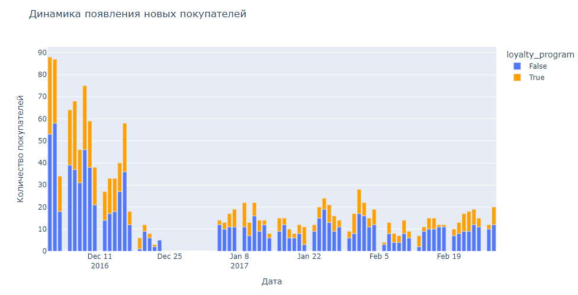

На графике видим сезонный пик прихода новых покупателей в начале декабря связаный с покупкой подарков, далее видим перерыв в работе сети в конце декабря начале января соответсвующий рождественским праздничным дням и стабилизацию графика после 03.01. Среди новых покупателей стабильно меньше участников программы лояльности почти на всем временном промежутке.

Обьявим функцию для расчета LTV.

```python
def get_ltv(
    profiles,  # Шаг 1. Получить профили и данные о покупках
    purchases,
    observation_date,
    horizon_days,
    dimensions=[],
    ignore_horizon=False,
):

    # исключаем покупателей, не «доживших» до горизонта анализа
    last_suitable_acquisition_date = observation_date
    if not ignore_horizon:
        last_suitable_acquisition_date = observation_date - timedelta(
            days=horizon_days - 1
        )
    result_raw = profiles.query('dt <= @last_suitable_acquisition_date')

    # Шаг 2. Добавить данные о покупках в профили

    result_raw = result_raw.merge(
        # добавляем в профили время совершения покупок и выручку
        purchases[[ 'customer_id', 'purchase_datetime', 'revenue']],
        on='customer_id',
        how='left',
    )

    # Шаг 3. Рассчитать лайфтайм покупателя для каждой покупки
    result_raw['lifetime'] = (
        result_raw['purchase_datetime'] - result_raw['first_ts']
    ).dt.days

    # группируем по cohort, если в dimensions ничего нет
    if len(dimensions) == 0:
        result_raw['cohort'] = 'All users'
        dimensions = dimensions + ['cohort']

    # функция для группировки таблицы по желаемым признакам
    def group_by_dimensions(df, dims, horizon_days):

        # Шаг 4. Построить таблицу выручки
        # строим «треугольную» таблицу
        result = df.pivot_table(
            index=dims,
            columns='lifetime',
            values='revenue',  # в ячейках — выручка за каждый лайфтайм
            aggfunc='sum',
        )

        # Шаг 5. Посчитать сумму выручки с накоплением
        result = result.fillna(0).cumsum(axis=1)

        # Шаг 6. Вычислить размеры когорт
        cohort_sizes = (
            df.groupby(dims)
            .agg({'customer_id': 'nunique'})
            .rename(columns={'customer_id': 'cohort_size'})
        )

        # Шаг 7. Объединить размеры когорт и таблицу выручки
        result = cohort_sizes.merge(result, on=dims, how='left').fillna(0)

        # Шаг 8. Посчитать LTV
        # делим каждую «ячейку» в строке на размер когорты
        result = result.div(result['cohort_size'], axis=0)
        # исключаем все лайфтаймы, превышающие горизонт анализа
        result = result[['cohort_size'] + list(range(horizon_days))]
        # восстанавливаем размеры когорт
        result['cohort_size'] = cohort_sizes
        return result

    # получаем таблицу LTV
    result_grouped = group_by_dimensions(result_raw, dimensions, horizon_days)

    # для таблицы динамики LTV убираем 'cohort' из dimensions
    if 'cohort' in dimensions:
        dimensions = []
    # получаем таблицу динамики LTV
    result_in_time = group_by_dimensions(
        result_raw, dimensions + ['dt'], horizon_days
    )

    # возвращаем обе таблицы LTV и сырые данные
    return result_raw, result_grouped, result_in_time
```

```python
ltv_raw, ltv, ltv_history = get_ltv(
    profiles, data_filtr, datetime(2017, 2, 28).date(), 75,  dimensions=['loyalty_program'], ignore_horizon=False
)
```

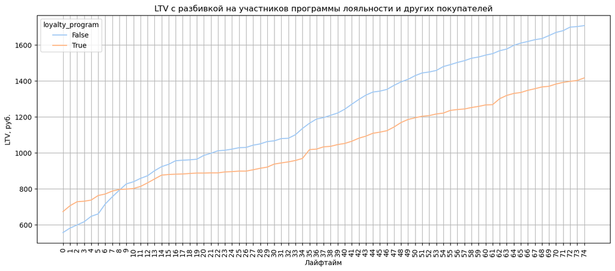

```python
# строим кривые LTV
report = ltv.drop(columns=['cohort_size'])
report.T.plot(grid=True, figsize=(15, 6), xticks=list(report.columns.values))
plt.title('LTV с разбивкой на участников программы лояльности и других покупателей')
plt.ylabel('LTV, руб.')
plt.xlabel('Лайфтайм')
plt.xticks(rotation=90)
plt.show()
```

В начале участники программы лояльности приносили больше выручки чем другие покупатели, но спустя неделю ситуация изменилась и LTV покупателей не задействованных в программе лояльности увеличилось. Темпы роста LTV участников программы лояльности ниже чем у других покупателей.

## Проверка статистических гипотез

### Средний чек участников программы лояльности выше, чем у остальных покупателей.

Проверим данные на нормальность с помошью критерия Шапиро-Уилка.

```python
avg_bill_lp = data_filtr.query('loyalty_program==1').groupby('purchase_id')['total'].sum().values
avg_bill_all = data_filtr.query('loyalty_program==0').groupby('purchase_id')['total'].sum().values

alpha = 0.05  # критический уровень статистической значимости
results = st.shapiro(avg_bill_lp)
p_value = results[1]  # второе значение в массиве результатов (с индексом 1) - p-value
print('p-значение: ', p_value)
if p_value < alpha:
    print('Отвергаем нулевую гипотезу: распределение не нормально')
else:
    print('Не получилось отвергнуть нулевую гипотезу, всё нормально')
```

```
p-значение:  0.0
Отвергаем нулевую гипотезу: распределение не нормально
```

```python
alpha = 0.05  # критический уровень статистической значимости
results = st.shapiro(avg_bill_all)
p_value = results[1]  # второе значение в массиве результатов (с индексом 1) - p-value
print('p-значение: ', p_value)
if p_value < alpha:
    print('Отвергаем нулевую гипотезу: распределение не нормально')
else:
    print('Не получилось отвергнуть нулевую гипотезу, всё нормально')
```

```
p-значение:  0.0
Отвергаем нулевую гипотезу: распределение не нормально
```

Критерий Шапиро-Уилка показал, что данные распределены не нормально, потому для проверки гипотез будем пользоватся непараметрическим тестом Уилкоксона-Манна-Уитни.

Выдвенем гипотезы:

- Н0: Средний чек участников программы лояльности равен среднему чеку остальных покупателей.
- Н1: Средний чек участников программы лояльности выше, чем у остальных покупателей.

```python
alpha = 0.05  # критический уровень статистической значимости

results = st.mannwhitneyu(avg_bill_all, avg_bill_lp, True, 'less')

print('p-значение: ', results.pvalue)

if results.pvalue<alpha:
    print('Отвергаем нулевую гипотезу: разница статистически значима')
else:
    print('Не получилось отвергнуть нулевую гипотезу, вывод о различии сделать нельзя')
```

```
p-значение:  0.9648676145926367
Не получилось отвергнуть нулевую гипотезу, вывод о различии сделать нельзя
```

Согласно тесту Уилкоксона-Манна-Уитни средний чек участников программы лояльности статистически значимо не отличается от среднего чека остальных покупателей.

### Среднее количество товаров в чеке у участников программы лояльности выше, чем у остальных покупателей.

Проверим данные на нормальность с помошью критерия Шапиро-Уилка.

```python
qu_lp = data_filtr.query('loyalty_program==1').groupby('purchase_id')['quantity'].sum().values
qu_all = data_filtr.query('loyalty_program==0').groupby('purchase_id')['quantity'].sum().values

alpha = 0.05  # критический уровень статистической значимости
results = st.shapiro(qu_lp)
p_value = results[1]  # второе значение в массиве результатов (с индексом 1) - p-value
print('p-значение: ', p_value)
if p_value < alpha:
    print('Отвергаем нулевую гипотезу: распределение не нормально')
else:
    print('Не получилось отвергнуть нулевую гипотезу, всё нормально')
```

```
p-значение:  4.203895392974451e-45
Отвергаем нулевую гипотезу: распределение не нормально
```

```python
alpha = 0.05  # критический уровень статистической значимости
results = st.shapiro(qu_all)
p_value = results[1]  # второе значение в массиве результатов (с индексом 1) - p-value
print('p-значение: ', p_value)
if p_value < alpha:
    print('Отвергаем нулевую гипотезу: распределение не нормально')
else:
    print('Не получилось отвергнуть нулевую гипотезу, всё нормально')
```

```
p-значение:  0.0
Отвергаем нулевую гипотезу: распределение не нормально
```

Критерий Шапиро-Уилка показал, что данные распределены не нормально, потому для проверки гипотез будем пользоватся непараметрическим тестом Уилкоксона-Манна-Уитни.

Выдвенем гипотезы:

- Н0: Среднее количество товаров в чеке участников программы лояльности и остальных покупателей равно.
- Н1: Среднее количество товаров в чеке у участников программы лояльности выше чем у остальных покупателей.

```python
alpha = 0.05  # критический уровень статистической значимости

results = st.mannwhitneyu(qu_all, qu_lp, True, 'less')

print('p-значение: ', results.pvalue)

if results.pvalue<alpha:
    print('Отвергаем нулевую гипотезу: разница статистически значима')
else:
    print('Не получилось отвергнуть нулевую гипотезу, вывод о различии сделать нельзя')
```

```
p-значение:  0.9434811389108051
Не получилось отвергнуть нулевую гипотезу, вывод о различии сделать нельзя
```

Согласно тесту Уилкоксона-Манна-Уитни среднее количество товаров в чеке участников программы лояльности и остальных покупателей статистически значимо не отличается.

В ходе проверки гипотез мы проверили данные на нормальность при помощи критерия Шапиро-Уилка, критерий показал, что распределения не нормальны потому для проверки гипотез использовали тест Уилкоксона-Манна-Уитни. Удалось выяснить что:

- средний чек участников программы лояльности статистически значимо не отличается от среднего чека остальных покупателей;
- среднее количество товаров в чеке участников программы лояльности и остальных покупателей статистически значимо не отличается.

## Выводы

Мы проанализировали данные о программе лояльности магазина строительных материалов «Строили, строили и наконец построили» за период: 89 дней с 01.12.2016 по 28.02.2017 и оценили результаты внедрения программы.

В ходе анализа мы провели предобработку данных, исследовательский анализ данных, исследовали среднее количество покупок, среднее количество товаров в чеке, средний чек, LTV, проверили статистические гипотезы о том, что средний чек и количество товаров в чеке участников программы лояльности выше, чем у остальных покупателей.

Сделали следующие выводы:

Участники программы лояльности не покупают чаще, не покупают больше товаров, не имеют больший средний чек и LTV чем остальные покупатели. Так же у нас нет данных о затратах на программу лояльности, возможно ситуация еще хуже. Программа лояльности не работает, возможно ее следует видоизменить, чтобы привлечь больше покупателей либо закрыть и попробовать другие варианты мотивации покупателей.

## Материалы:

- Презентация: https://disk.yandex.ru/i/O6wTUEYAUxvH7w
- Дашборд: https://public.tableau.com/shared/7QD9XR5DZ?:display_count=n&:origin=viz_share_link